# Practicum data-analyse met R

Witek ten Hove

september 2017

Zie voor informatie over R de bijbehorende [workshop](https://witusj.github.io/WorkshopSI/)

## Stap 1: data ophalen

In dit geval is de databron een SPSS bestand. Hiervoor kunnen we de `foreign` `package` gebruiken. We laden ook een andere handige `package` waar een aantal handige functies in zitten voor databewerking (filteren, transformeren, etc.).

`Packages` zijn verzamelingen van functies rondom thema’s. Sommige `packages` zitten bij de standaard installatie van R (zoals `foreign`). Andere (zoals `tidyverse`) dien je zelf te installeren met de `install.packages()` functie of via je de install knop in RStudio.

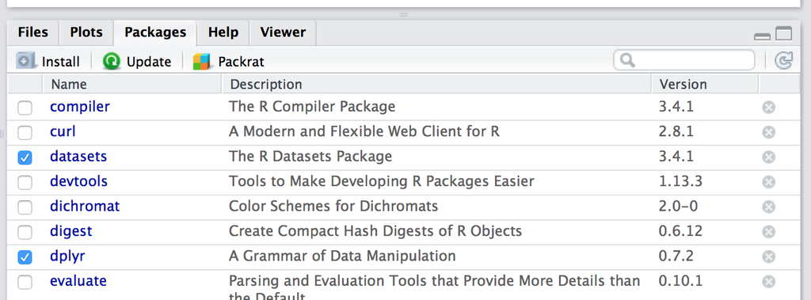

In dit geval staat het bestand online, maar je kunt ook verwijzen naar een bestand dat je lokaal hebt opgeslagen. R biedt legio mogelijkheden om verschillende bestandsformaten in te lezen. Zo kun je bijvoorbeeld rechtstreeks uit een database lezen of uit een [Google Spreadsheet](https://cran.r-project.org/web/packages/gsheet/gsheet.pdf) (die bijvoorbeeld gekoppeld is aan een Google Form).

De ingelezen data wijzen we toe aan een variabele `rawData`. De naam van de variabele is een arbitraire keuze. Zorg er echter altijd voor dat je een unieke naam kiest voor een variabele. Tenzij het je expliciete bedoeling is de data die in de variabele is opgeslagen te overschrijven.

```r
library(foreign)
library(tidyverse)
rawData <- read.spss("https://github.com/witusj/onderzoek/blob/master/files/enqu%C3%AAte%20woonwensen%20studenten%202016%20data%20in%20SPSS.sav?raw=true", to.data.frame = TRUE)
```

```
Undeclared level(s) 3 added in variable: Geslacht
```

## Stap 2: structuur en kwaliteit van de data beoordelen

Met de functie `str()` kunnen we een globaal overzicht krijgen van de *structuur* van de data.

```r
str(rawData)
```

```
'data.frame':   269 obs. of  35 variables:
 $ WoSitnu    : Factor w/ 6 levels "Bij ouders","Op kamers (gedeeld gebruik san. en/of keuken)",..: 1 1 1 1 1 1 1 1 1 1 ...
 $ WoOppnu    : num  14 NA NA NA NA NA NA NA 4 5 ...
 $ WoLastnu   : num  NA NA NA NA NA NA NA 150 NA 500 ...
 $ WoGemstu   : Factor w/ 2 levels "ja","nee": 2 2 2 2 1 2 2 2 1 2 ...
 $ Reistijd   : Factor w/ 6 levels "minder dan 10 min.",..: 4 3 5 5 2 5 6 3 3 3 ...
 $ Tevreden   : num  7 9 7 8 9 10 10 8 8 8 ...
 $ Toelicht   : Factor w/ 118 levels "                                                                                                               "| __truncated__,..: 31 50 109 1 1 1 1 105 107 1 ...
 $ Verhuisplan: Factor w/ 6 levels "ja, zeer korte termijn",..: 6 5 6 6 4 6 4 4 5 5 ...
 $ VMsituatie : Factor w/ 2 levels "niet","wel": NA NA NA NA 2 NA 2 2 NA NA ...
 $ VMprijs    : Factor w/ 2 levels "niet","wel": NA NA NA NA 2 NA 1 2 NA NA ...
 $ VMcampus   : Factor w/ 2 levels "niet","wel": NA NA NA NA 2 NA 1 1 NA NA ...
 $ VMcentrum  : Factor w/ 2 levels "niet","wel": NA NA NA NA 2 NA 1 2 NA NA ...
 $ VMhuisgenot: Factor w/ 2 levels "niet","wel": NA NA NA NA 2 NA 1 2 NA NA ...
 $ VMverplicht: Factor w/ 2 levels "niet","wel": NA NA NA NA 2 NA 1 1 NA NA ...
```

[output cut: 24 more lines]

Het blijkt dat de data is opgeslagen als een *data frame*. Dit het het standaard formaat, waarmee R werkt en het kan in principe als een gewone tabel worden beschouwd met rijen en kolommen. Iedere rij is een observatie (in dit geval 269 rijen / observaties) en iedere kolom een variabele (35). We hebben dus een variabele `rawData` gedefinieerd die een tabel bevat met observaties en variabelen. Een variabele kan dus weer een verzameling van variabelen bevatten.

Iedere variabele uit de tabel heeft een unieke naam, waarnaar kan worden gerefereerd. De elementen in de variabele (kolom) zijn geindexeerd en kunnen worden opgeroepen.

```r
head(rawData$WoLastwens, 10)
```

```
 [1] 500  NA 400 300 400 500 400 400  20 300
```

```r
rawData$WoLastwens[c(1, 4)]
```

```
[1] 500 300
```

De `c vector` is een speciaal object binnen R. Hier kun je allerlei elementen in opslaan, die je als één `vector` of `list` (= een verzameling van `vectoren`) wilt gebruiken. De elementen kunnen zowel tekst als cijfers zijn (en combinaties daarvan).

**Tussenvraag 1:** Wat doet de functie `head()`?

Met de functie `summary()` kan de kwaliteit van de ruwe data worden beoordeeld.

```r
summary(rawData)
```

```
                                          WoSitnu       WoOppnu
 Bij ouders                                   :202   Min.   : 4.00
 Op kamers (gedeeld gebruik san. en/of keuken): 48   1st Qu.:12.00
 Eenkamerwoning met eigen voorzieningen       :  3   Median :16.00
 zelfstandige huurwoning                      : 11   Mean   :20.42
 zelfstandige koopwoning                      :  1   3rd Qu.:23.00
 anders                                       :  4   Max.   :80.00
                                                     NA's   :16
    WoLastnu     WoGemstu                Reistijd     Tevreden
 Min.   : 30.0   ja : 80   minder dan 10 min.:39   Min.   : 3.000
 1st Qu.:300.0   nee:189   10-20 min.        :36   1st Qu.: 7.000
 Median :350.0             21-40 min.        :56   Median : 8.000
 Mean   :384.8             41-60 min.        :55   Mean   : 8.048
 3rd Qu.:438.8             61-90 min.        :57   3rd Qu.: 9.000
 Max.   :900.0             langer dan 90 min.:26   Max.   :10.000
 NA's   :191
                                                                                                                                                                                                                                                       Toelicht
                                                                                                                                                                                                                                                           :151
 nee                                                                                                                                                                                                                                                       :  2
 -                                                                                                                                                                                                                                                         :  1
 Alles is redelijk dichtbij.                                                                                                                                                                                                                               :  1
 Alles wordt geregeld                                                                                                                                                                                                                                      :  1
 Beetje klein maar heel dicht bij het station. Niet hele leuke huisgenoten.                                                                                                                                                                                :  1
 (Other)                                                                                                                                                                                                                                                   :112
                               Verhuisplan  VMsituatie VMprijs    VMcampus
 ja, zeer korte termijn              :  7   niet: 36   niet: 85   niet: 47
 ja, binnen half jaar                : 29   wel : 75   wel : 26   wel : 64
 ja, over een  half jaar tot een jaar: 43   NA's:158   NA's:158   NA's:158
 ja, over meer dan 1 jaar            : 32
 nee, voorlopig niet van pan         :124
 weet ik  (nog)  niet                : 34

 VMcentrum  VMhuisgenot VMverplicht VMander      WoOppwens       WoLastwens
 niet: 52   niet: 64    niet:105    niet: 95   Min.   : 5.00   Min.   :  20.0
 wel : 59   wel : 47    wel :  6    wel : 16   1st Qu.:15.00   1st Qu.: 350.0
 NA's:158   NA's:158    NA's:158    NA's:158   Median :18.00   Median : 400.0
                                               Mean   :20.36   Mean   : 406.9
                                               3rd Qu.:20.00   3rd Qu.: 450.0
                                               Max.   :80.00   Max.   :1000.0
                                               NA's   :23      NA's   :21
```

[output cut: 37 more lines]

```
             3rd Qu.:   1997   3rd Qu.: 850.0
             Max.   :1994350   Max.   :2500.0
                               NA's   :1
                                                                                                                                                                                                                                                     Opmerkingen
                                                                                                                                                                                                                                                           :124
 Nee                                                                                                                                                                                                                                                       : 39
 nee                                                                                                                                                                                                                                                       : 34
 -                                                                                                                                                                                                                                                         :  7
 Nope                                                                                                                                                                                                                                                      :  3
 /                                                                                                                                                                                                                                                         :  1
 (Other)                                                                                                                                                                                                                                                   : 61
         filter_.
 Not Selected:  1
 Selected    :247
 NA's        : 21
```

Een aantal variabelen bevatten lege waarden (NA = Not Available). We kunnen die eruit filteren met de `na.omit()` functie. Alle observaties die lege waarden bevatten, zijn nu weggefilterd. Merk op dat de schone data set nu in een nieuwe variabele is opgeslagen `myData`. We beschikken nu dus over twee data sets: één met de ruwe en een andere met de opgeschoonde data.

```r
myData <- rawData %>% na.omit()
cat("De nieuwe data set bevat ", dim(myData)[1], " rijen", "\nDe oude data set bevat ", dim(rawData)[1], " rijen\n")
```

```
De nieuwe data set bevat  30  rijen
De oude data set bevat  269  rijen
```

```r
summary(myData)
```

```
                                          WoSitnu      WoOppnu
 Bij ouders                                   : 8   Min.   : 8.00
 Op kamers (gedeeld gebruik san. en/of keuken):14   1st Qu.:13.25
 Eenkamerwoning met eigen voorzieningen       : 2   Median :18.00
 zelfstandige huurwoning                      : 3   Mean   :22.53
 zelfstandige koopwoning                      : 0   3rd Qu.:24.50
 anders                                       : 3   Max.   :80.00

    WoLastnu     WoGemstu               Reistijd     Tevreden
 Min.   : 30.0   ja :18   minder dan 10 min.: 6   Min.   : 3.000
 1st Qu.:291.8   nee:12   10-20 min.        :11   1st Qu.: 6.250
 Median :324.5            21-40 min.        : 1   Median : 7.000
 Mean   :378.3            41-60 min.        : 2   Mean   : 6.967
 3rd Qu.:398.8            61-90 min.        : 6   3rd Qu.: 8.000
 Max.   :900.0            langer dan 90 min.: 4   Max.   :10.000

                                                                                                                                                                                                                                                       Toelicht
                                                                                                                                                                                                                                                           :20
 Beetje klein maar heel dicht bij het station. Niet hele leuke huisgenoten.                                                                                                                                                                                : 1
 De locatie is ideaal, maar het is een ongezellig huis                                                                                                                                                                                                     : 1
 De prijs is relatief laag, maar de privacy ook                                                                                                                                                                                                            : 1
 gezellig huis                                                                                                                                                                                                                                             : 1
 Het huis is slecht onderhouden. Ik zou graag mijn eigen plek willen waarbij ik mijn keuken, wc en badkamer niet hoef te delen met huisgenoten, maar dat is onmogelijk te krijgen voor een betaalbare prijs in Nijmegen.                                   : 1
 (Other)                                                                                                                                                                                                                                                   : 5
                               Verhuisplan VMsituatie VMprijs   VMcampus
 ja, zeer korte termijn              : 2   niet:15    niet:14   niet:20
 ja, binnen half jaar                :10   wel :15    wel :16   wel :10
 ja, over een  half jaar tot een jaar:11
 ja, over meer dan 1 jaar            : 7
 nee, voorlopig niet van pan         : 0
 weet ik  (nog)  niet                : 0

 VMcentrum VMhuisgenot VMverplicht VMander     WoOppwens      WoLastwens
 niet:22   niet:19     niet:25     niet:25   Min.   :10.0   Min.   : 250.0
 wel : 8   wel :11     wel : 5     wel : 5   1st Qu.:15.0   1st Qu.: 357.5
                                             Median :16.0   Median : 435.0
                                             Mean   :20.8   Mean   : 482.5
                                             3rd Qu.:21.5   3rd Qu.: 587.5
                                             Max.   :60.0   Max.   :1000.0

```

[output cut: 36 more lines]

```
            Mean   :1994   Mean   : 931.7   Facility Management      :9
            3rd Qu.:1996   3rd Qu.:1075.0
            Max.   :1998   Max.   :2000.0

                                                                                                                                                                                                                                                     Opmerkingen
                                                                                                                                                                                                                                                           :16
 Nee                                                                                                                                                                                                                                                       : 7
 -                                                                                                                                                                                                                                                         : 2
 /                                                                                                                                                                                                                                                         : 1
 Alle vragen gingen vanuit dat je op kamers woont of op kamers wil. Dus voor mij waren veel vragen n.v.t.                                                                                                                                                  : 1
 nee                                                                                                                                                                                                                                                       : 1
 (Other)                                                                                                                                                                                                                                                   : 2
         filter_.
 Not Selected: 1
 Selected    :29
```

**Tussenvraag 2:** Wat doen de functies `cat()` en `dim()`?

We zien nu echter dat ongeveer 89% van de data is verdwenen. Dit is zeer onwenselijk en we zullen dus anders moeten omgaan met lege waarden. Hier komen we later op terug.

## Stap 3: Visuele inspectie

De meeste mensen zijn beter in het beoordelen van data in grafische vorm dan als tabel. De standaar installatie van R bevat een aantal goede standaard functies voor grafieken. Een veelgebruikte `package` is echter `ggplot2`. Deze hebben we al eerder geladen met de `package` `tidyverse`.

We kunnen kijken of er verbanden bestaan tussen huidige woonsituatie en de woonoppervlakte.

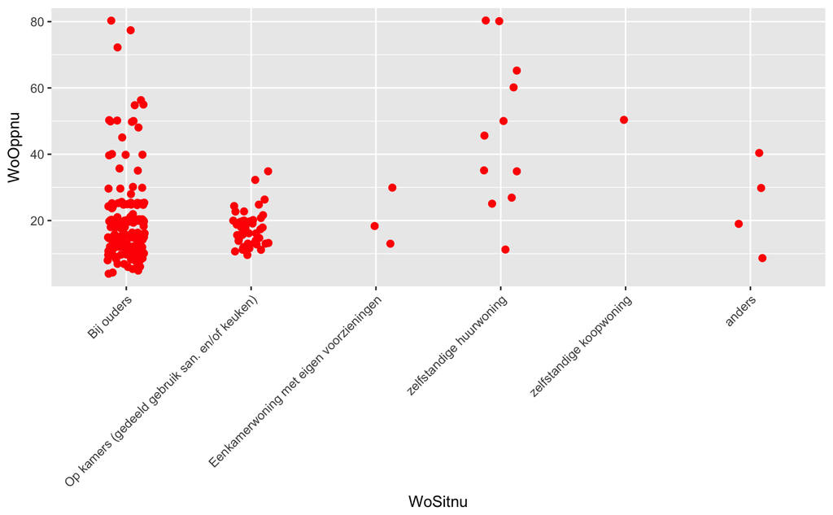

```r
myPlot <- ggplot(rawData, aes(x = WoSitnu, y = WoOppnu)) +
  geom_jitter(colour = 'red', size = 2, width = 0.15) +
  # Voeg hier een nieuwe layer toe met geom_point() +
  theme(axis.text.x = element_text(angle = 45, hjust = 1))
myPlot
```

`ggplot` werkt met `layers`. Als eerste definieren we de databron (in ons geval `rawData`) en de x- en y-variabelen (`WoSitnu` en `WoOppnu`).

De volgende `layer` is de `geom_jitter()` functie. Als we de punten zo maar in de grafiek zouden laten tekenen, zou er veel overlap zijn. Door wat `random noise` toe te voegen, worden alle punten zichtbaar en wordt de spreiding beter zichtbaar. We kunnen hier onder andere de kleur en de grootte van de punten instellen en hoe ver ze van elkaar verspreid worden (mate van `noise`).

De laatste `layer` - `theme()` - bepaalt de opmaak van grafiek. Hier kunnen we de orientatie van de tekstlabels op de x-as opgeven en de leesbaarheid verhogen.

We zien dat de meeste studenten bij hun ouders wonen. Studenten met een eigen kamer hebben een kleiner woonoppervlakte opgegeven. Het is nog de vraag of thuiswondende studenten daadwerkelijk een kamer hebben van 80 m2 of dat de vraag niet helemaal duidelijk voor ze was. In ieder geval is dit een punt dat tijdens het ontwerp van een enquete getest en onderzocht dient te worden.

**Tussenvraag 3:** Voeg een layer toe met `geom_point()`, geef het de kleur blauw en bekijk het verschil.

## Stap 4: Data voorbereiding

We hebben al eerder getracht de kwaliteit van de data te verbeteren door alle NA’s te elimineren. Daarmee hielden we de observaties over die volledig compleet waren. Echter hiermee werd de omvang van de data extreem klein, wat een probleem kan betekenen voor de betrouwbaarheid van eventuele statistische toetsen.

We kunnen eens kijken welke `variabelen` veel NA’s bevatten. Hiervoor moeten we eerst de kolommen selecteren die numerieke waarden bevatten.

```r
nums <- sapply(rawData, is.numeric)
numData <- rawData[,nums]
head(numData)
```

|  | WoOppnu | WoLastnu | Tevreden | WoOppwens | WoLastwens | Gebjaar | Inkomen |
| --- | --- | --- | --- | --- | --- | --- | --- |
| 1 | 14 | NA | 7 | 15 | 500 | 1997 | 300 |
| 2 | NA | NA | 9 | 50 | NA | 1998 | 51 |
| 3 | NA | NA | 7 | 20 | 400 | 1997 | 120 |
| 4 | NA | NA | 8 | NA | 300 | 1998 | 250 |
| 5 | NA | NA | 9 | 30 | 400 | 1998 | 300 |
| 6 | NA | NA | 10 | 45 | 500 | 1998 | 450 |

De functie `sapply()` past op iedere variabele in een data frame (`rawData`), de opgegeven `functie` toe. In dit geval wordt per kolom op ieder element de functie `is. numeric` toegepast. Deze functie neemt een element en test of het element een getal is of niet. De uitkomst is een `boolean`, `TRUE` of `FALSE`.

Er zijn blijkbaar 7 kolommen met getallen. We kunnen nu snel het percentage NA’s bepalen per kolom.

```r
NAs <- sapply(numData, is.na) %>% as.data.frame
head(NAs)
```

|  | WoOppnu | WoLastnu | Tevreden | WoOppwens | WoLastwens | Gebjaar | Inkomen |
| --- | --- | --- | --- | --- | --- | --- | --- |
| 1 | FALSE | TRUE | FALSE | FALSE | FALSE | FALSE | FALSE |
| 2 | TRUE | TRUE | FALSE | FALSE | TRUE | FALSE | FALSE |
| 3 | TRUE | TRUE | FALSE | FALSE | FALSE | FALSE | FALSE |
| 4 | TRUE | TRUE | FALSE | TRUE | FALSE | FALSE | FALSE |
| 5 | TRUE | TRUE | FALSE | FALSE | FALSE | FALSE | FALSE |
| 6 | TRUE | TRUE | FALSE | FALSE | FALSE | FALSE | FALSE |

```r
NAs <- NAs * 1
summary(NAs)
```

```
    WoOppnu           WoLastnu       Tevreden   WoOppwens        WoLastwens
 Min.   :0.00000   Min.   :0.00   Min.   :0   Min.   :0.0000   Min.   :0.00000
 1st Qu.:0.00000   1st Qu.:0.00   1st Qu.:0   1st Qu.:0.0000   1st Qu.:0.00000
 Median :0.00000   Median :1.00   Median :0   Median :0.0000   Median :0.00000
 Mean   :0.05948   Mean   :0.71   Mean   :0   Mean   :0.0855   Mean   :0.07807
 3rd Qu.:0.00000   3rd Qu.:1.00   3rd Qu.:0   3rd Qu.:0.0000   3rd Qu.:0.00000
 Max.   :1.00000   Max.   :1.00   Max.   :0   Max.   :1.0000   Max.   :1.00000
    Gebjaar     Inkomen
 Min.   :0   Min.   :0.000000
 1st Qu.:0   1st Qu.:0.000000
 Median :0   Median :0.000000
 Mean   :0   Mean   :0.003717
 3rd Qu.:0   3rd Qu.:0.000000
 Max.   :0   Max.   :1.000000
```

In de eerste stap is ieder element uit de data.frame in de variabele `numData` getest op de hypothese: “Is een NA”. De uitkomst is een `boolean` (`TRUE` / `FALSE`). Door alle booleans te vermenigvuldigen met 1 worden het cijfers (`TRUE` = 1 / `FALSE` = 0). Dit wordt zichtbaar als we de `summary()` functie toepassen op de data frame. Iedere variabele bevat alleen twee soorten waarden: het minimum (= 0) en het maximum (= 1). Als we van iedere kolom het gemiddelde berekenen krijgen we de verhouding NAs per variabele. Voor de variabele `WoOppnu` is dat 5.9%.

**Tussenvraag 4:** Leg uit waarom het gemiddelde van de variabele het percentage NAs moet zijn.